# Stream C: Introduction to R Programming (BioinfoSummer 2015)

Pengyi Yang & Stephen Pederson

The R programming language provides an effective environment for making sense of data that enables us to address various biological questions. In this introduction course, we will illustrate exploratory data analysis that involves calculating numerical and graphical summaries. More specially, we will cover installation of R packages, write basic R functions and examine various visualization tools. For more intermediate participants in the course we will examine more complex visualization tools.

## Outline

- R data types and operations
- Read data in R and exploratory data analysis
- Install package and calling functions from packages
- Write your own functions
- Generating reports using RStudio

## R data types

#### Atomic data types and operations

Character

```r
species <- "mouse"
```

Integer

```r
sampleSize <- 6
```

Numeric

```r
meanLifeSpan <- 2.05
```

Factor

```r
sex <- factor("male")
```

Boolean

```r
mammal <- TRUE
```

Concatenate characters

```r
strain <- "C57BL/6"
sampleDetail <- paste(species, strain)
sampleDetail
```

```
## [1] "mouse C57BL/6"
```

#### Primitive data types and operations

Vectors

```r
Groups <- c("treated", "control", "control", "control", "treated", "treated")
Groups
```

```
## [1] "treated" "control" "control" "control" "treated" "treated"
```

Calculate mean life span of sample population

```r
lifeSpans <- c(2.1, 1.9, 1.7, 1.8, 2.3, 2.5)
lifeSpans
```

```
## [1] 2.1 1.9 1.7 1.8 2.3 2.5
```

```r
mean(lifeSpans)
```

```
## [1] 2.05
```

Split samples based on their groups

```r
sampleByGroup <- split(lifeSpans, Groups)
sampleByGroup # sampleByGroup is a list
```

```
## $control
## [1] 1.9 1.7 1.8
##
## $treated
## [1] 2.1 2.3 2.5
```

Test if there is statistical significance of life span between the two groups of samples

```r
g1 <- sampleByGroup$treated
g2 <- sampleByGroup$control
t.test(g1, g2, alternative="greater")
```

```
##
##  Welch Two Sample t-test
##
## data:  g1 and g2
## t = 3.873, df = 2.9412, p-value = 0.01578
## alternative hypothesis: true difference in means is greater than 0
## 95 percent confidence interval:
##  0.1936888       Inf
## sample estimates:
## mean of x mean of y
##       2.3       1.8
```

## Read data in R and exploratory data analysis

Read in a tab-delimited dataset from plain text file and calculate summary statistics

```r
Adipo.dat <- read.delim("Adipogenesis.txt", head=TRUE)
Adipo.dat[1:5,]
```

```
##   GeneSymbol    t0.5h      t1h      t2h       t4h        t8h       t48h
## 1      Nr4a1 4.139264 4.695290 4.557286 4.1127582  3.4080955  2.4537373
## 2        Fos 4.389225 4.093885 1.806750 1.2671636  0.8352796  0.5272506
## 3       Btg2 3.989989 3.995800 1.645890 0.7139266 -0.6195376 -0.4145120
## 4      Ptgs2 4.337712 5.460611 4.642035 3.0987586  1.3670011  0.7382098
## 5       Rgs2 2.822143 3.376263 3.523400 3.3030717  2.6106386  2.7989720
```

subsetting a matrix

```r
Adipo.exp <- as.matrix(Adipo.dat[,-1]) # removing the ID column from the raw data to create a numeric matrix containing the expression of the genes at each time point
rownames(Adipo.exp) <- Adipo.dat[,1] # assign the row names of the matrix as the ID in the first column
Adipo.exp[1:5,] # displaying the first five rows of the expression matrix
```

```
##          t0.5h      t1h      t2h       t4h        t8h       t48h
## Nr4a1 4.139264 4.695290 4.557286 4.1127582  3.4080955  2.4537373
## Fos   4.389225 4.093885 1.806750 1.2671636  0.8352796  0.5272506
## Btg2  3.989989 3.995800 1.645890 0.7139266 -0.6195376 -0.4145120
## Ptgs2 4.337712 5.460611 4.642035 3.0987586  1.3670011  0.7382098
## Rgs2  2.822143 3.376263 3.523400 3.3030717  2.6106386  2.7989720
```

```r
summary(Adipo.exp)
```

```
##      t0.5h                t1h                t2h
##  Min.   :-2.187384   Min.   :-1.90305   Min.   :-2.723784
##  1st Qu.:-0.051696   1st Qu.:-0.08715   1st Qu.:-0.123376
##  Median : 0.008043   Median :-0.01620   Median : 0.004174
##  Mean   : 0.010743   Mean   :-0.01216   Mean   :-0.003355
##  3rd Qu.: 0.070590   3rd Qu.: 0.05336   3rd Qu.: 0.106438
##  Max.   : 4.389225   Max.   : 5.46061   Max.   : 5.419228
##       t4h                 t8h                t48h
##  Min.   :-3.546043   Min.   :-4.57534   Min.   :-4.48677
##  1st Qu.:-0.143953   1st Qu.:-0.13082   1st Qu.:-0.11234
##  Median : 0.028906   Median : 0.07001   Median : 0.05885
##  Mean   : 0.003566   Mean   : 0.02734   Mean   : 0.02059
##  3rd Qu.: 0.154741   3rd Qu.: 0.21931   3rd Qu.: 0.19805
##  Max.   : 5.422899   Max.   : 5.22746   Max.   : 6.37389
```

Read data from R data object

```r
load("DEGs.RData") # This data contains differentially expressed genes
# subset the expression matrix to select only DE gene experssions
Adip.exp.DEGs <- Adipo.exp[DEGs,]
```

## Exploratory data analysis and visualisation

boxplot

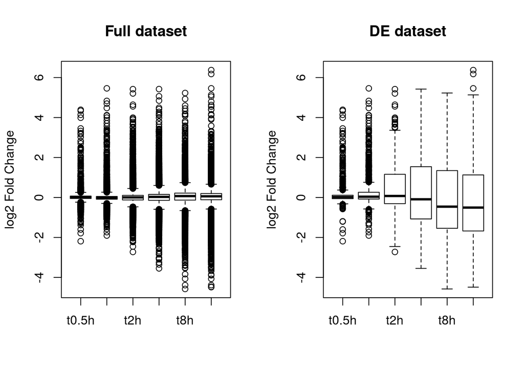

```r
par(mfrow=c(1, 2))
boxplot(Adipo.exp, ylab="log2 Fold Change", main="Full dataset")
boxplot(Adip.exp.DEGs, ylab="log2 Fold Change", main="DE dataset")
```

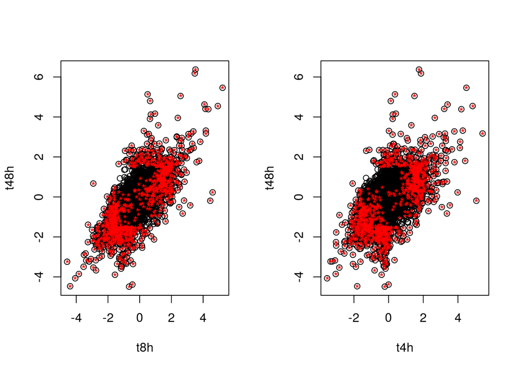

```r
par(mfrow=c(1, 2))
# Scatter plot the full data and highlight the DE genes in the scatter plot
plot(Adipo.exp[,c("t8h", "t48h")])
points(Adipo.exp[DEGs,c("t8h", "t48h")], pch="*", col="red", main="8h vs 48h")
# generating pairwise correlation plots
plot(Adipo.exp[,c("t4h", "t48h")])
points(Adipo.exp[DEGs,c("t4h", "t48h")], pch="*", col="red", main="4h vs 48h")
```

## Install R packages and runing Using cluster evaluation algorithm to determine optimal clusters in the time-series

Install a package called ClueR from CRAN (The Comprehensive R Archive Network)